# Amazon Sales Data Analysis

Maritza Jimenez

2024-09-10

**Summary:** The Amazon Sales Dataset, sourced from Kaggle, provides detailed information on over 1,000 products sold on Amazon’s website. It includes key attributes such as product names, categories, pricing, discounts, ratings, and customer reviews, offering valuable insights for sales trend analysis and consumer behavior studies.

Based on the available data, here are some key questions we could explore with stakeholders:

**Pricing Strategy Optimization:**

- How does the discount percentage correlate with the rating of the product? Are higher discounts leading to better ratings?
- What is the average price difference between actual and discounted prices across different categories?
- Which products have the smallest difference between actual price and discounted price, and do they have higher sales or ratings?

**Customer Behavior Analysis:**

- What is the distribution of ratings across different categories? Are there categories that consistently receive higher or lower ratings?
- How does the number of reviews (rating count) correlate with the product rating?
- Which products have the highest review count but the lowest ratings, indicating potential quality issues?

# Load data into R studio

```r
library(tidyverse)
library(dplyr)
library(ggplot2)
library(corrplot)
```

### How is the data organized

```r
dim(AmazonSalesData)
```

```
## [1] 1465   16
```

Data has 1465 observations (rows) and 16 variables (columns)

```r
colnames(AmazonSalesData)
```

```
##  [1] "product_id"          "product_name"        "category"
##  [4] "discounted_price"    "actual_price"        "discount_percentage"
##  [7] "rating"              "rating_count"        "about_product"
## [10] "user_id"             "user_name"           "review_id"
## [13] "review_title"        "review_content"      "img_link"
## [16] "product_link"
```

```r
sum(is.na(AmazonSalesData))
```

```
## [1] 0
```

Data is complete with no missing values.

### Clean the Data

```r
glimpse(AmazonSalesData)
```

```
## Rows: 1,465
## Columns: 16
## $ product_id          <chr> "B07JW9H4J1", "B098NS6PVG", "B096MSW6CT", "B08HDJ8…
## $ product_name        <chr> "Wayona Nylon Braided USB to Lightning Fast Chargi…
## $ category            <chr> "Computers&Accessories|Accessories&Peripherals|Cab…
## $ discounted_price    <chr> "₹399", "₹199", "₹199", "₹329", "₹154", "₹149", "₹…
## $ actual_price        <chr> "₹1,099", "₹349", "₹1,899", "₹699", "₹399", "₹1,00…
## $ discount_percentage <chr> "64%", "43%", "90%", "53%", "61%", "85%", "65%", "…
## $ rating              <chr> "4.2", "4.0", "3.9", "4.2", "4.2", "3.9", "4.1", "…
## $ rating_count        <chr> "24,269", "43,994", "7,928", "94,363", "16,905", "…
## $ about_product       <chr> "High Compatibility : Compatible With iPhone 12, 1…
## $ user_id             <chr> "AG3D6O4STAQKAY2UVGEUV46KN35Q,AHMY5CWJMMK5BJRBBSNL…
## $ user_name           <chr> "Manav,Adarsh gupta,Sundeep,S.Sayeed Ahmed,jaspree…
## $ review_id           <chr> "R3HXWT0LRP0NMF,R2AJM3LFTLZHFO,R6AQJGUP6P86,R1KD19…
## $ review_title        <chr> "Satisfied,Charging is really fast,Value for money…
## $ review_content      <chr> "Looks durable Charging is fine tooNo complains,Ch…
## $ img_link            <chr> "https://m.media-amazon.com/images/W/WEBP_402378-T…
## $ product_link        <chr> "https://www.amazon.in/Wayona-Braided-WN3LG1-Synci…
```

All the variables are currently stored as characters, which could lead to issues when performing mathematical calculations later on.

```r
# Remove special characters and convert to numeric
AmazonSalesData$discounted_price <- as.numeric(gsub("[₹,]", "", AmazonSalesData$discounted_price))
AmazonSalesData$actual_price <- as.numeric(gsub("[₹,]", "", AmazonSalesData$actual_price))
AmazonSalesData$discount_percentage <- as.numeric(gsub("%", "", AmazonSalesData$discount_percentage))
AmazonSalesData$rating <- as.numeric(AmazonSalesData$rating)
AmazonSalesData$rating_count <- as.numeric(gsub(",", "", AmazonSalesData$rating_count))

glimpse(AmazonSalesData)
```

```
## Rows: 1,465
## Columns: 16
## $ product_id          <chr> "B07JW9H4J1", "B098NS6PVG", "B096MSW6CT", "B08HDJ8…
## $ product_name        <chr> "Wayona Nylon Braided USB to Lightning Fast Chargi…
## $ category            <chr> "Computers&Accessories|Accessories&Peripherals|Cab…
## $ discounted_price    <dbl> 399.00, 199.00, 199.00, 329.00, 154.00, 149.00, 17…
## $ actual_price        <dbl> 1099, 349, 1899, 699, 399, 1000, 499, 299, 999, 29…
## $ discount_percentage <dbl> 64, 43, 90, 53, 61, 85, 65, 23, 50, 33, 55, 63, 69…
## $ rating              <dbl> 4.2, 4.0, 3.9, 4.2, 4.2, 3.9, 4.1, 4.3, 4.2, 4.0, …
## $ rating_count        <dbl> 24269, 43994, 7928, 94363, 16905, 24871, 15188, 30…
## $ about_product       <chr> "High Compatibility : Compatible With iPhone 12, 1…
## $ user_id             <chr> "AG3D6O4STAQKAY2UVGEUV46KN35Q,AHMY5CWJMMK5BJRBBSNL…
## $ user_name           <chr> "Manav,Adarsh gupta,Sundeep,S.Sayeed Ahmed,jaspree…
## $ review_id           <chr> "R3HXWT0LRP0NMF,R2AJM3LFTLZHFO,R6AQJGUP6P86,R1KD19…
## $ review_title        <chr> "Satisfied,Charging is really fast,Value for money…
## $ review_content      <chr> "Looks durable Charging is fine tooNo complains,Ch…
## $ img_link            <chr> "https://m.media-amazon.com/images/W/WEBP_402378-T…
## $ product_link        <chr> "https://www.amazon.in/Wayona-Braided-WN3LG1-Synci…
```

We’ve converted some characters into numeric values, but it’s important to remember that the monetary figures are in rupees. We also received a notice indicating that some NAs were introduced during the conversion. Let’s double-check the data and remove those rows, as missing values won’t be useful for our analysis.

```r
sum(is.na(AmazonSalesData))
```

```
## [1] 3
```

3 rows have NAs. We will go ahead and remove them as removing 3 rows won’t hinder much of our analysis.

```r
AmazonSalesDataClean <- na.omit(AmazonSalesData)
```

```r
sum(is.na(AmazonSalesDataClean))
```

```
## [1] 0
```

Now we have no more missing data and can continue on with our analysis.

```r
duplicates <- AmazonSalesDataClean[duplicated(AmazonSalesDataClean) | duplicated(AmazonSalesDataClean, fromLast = TRUE), ]
print(duplicates)
```

```
##  [1] product_id          product_name        category
##  [4] discounted_price    actual_price        discount_percentage
##  [7] rating              rating_count        about_product
## [10] user_id             user_name           review_id
## [13] review_title        review_content      img_link
## [16] product_link
## <0 rows> (or 0-length row.names)
```

We don’t have any duplicates in our dataset.

# Analysis

Starting off with our Pricing Strategy Optimization questions:

1. **Pricing Strategy Optimization:**
   - How does the discount percentage correlate with the rating of the product? Are higher discounts leading to better ratings?
   - What is the average price difference between actual and discounted prices across different categories?
   - Which products have the smallest difference between actual price and discounted price, and do they have higher sales or ratings?

```r
correlation <- cor(AmazonSalesDataClean$discount_percentage, AmazonSalesDataClean$rating, use = "complete.obs")
print(correlation)
```

```
## [1] -0.155679
```

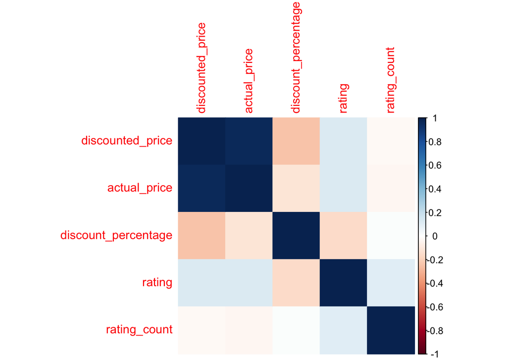

```r
corrplot(cor(AmazonSalesDataClean[, c("discounted_price", "actual_price", "discount_percentage", "rating", "rating_count")], use = "complete.obs"), method = "color")
```

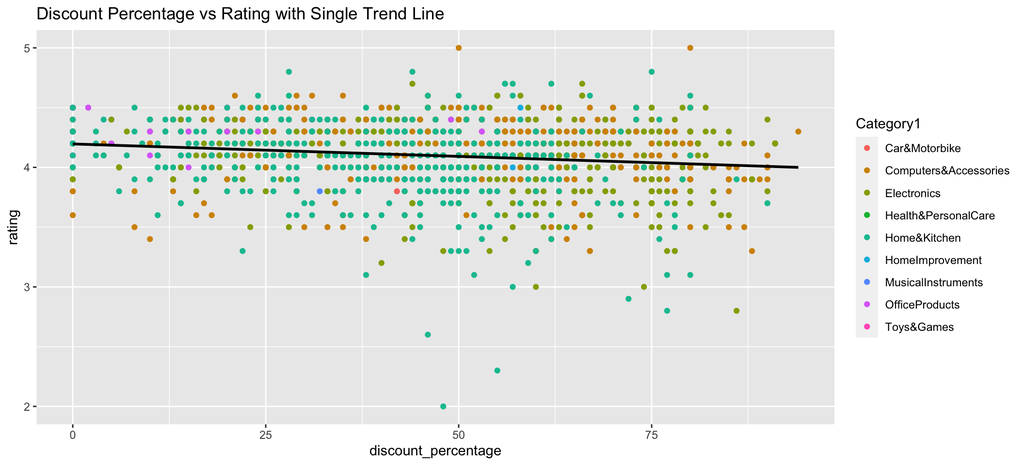

```r
ggplot(AmazonSalesDataCategories, aes(x = discount_percentage, y = rating)) +
  geom_point(aes(color = Category1)) +
  geom_smooth(method = "lm", se = FALSE, color = "black") +
  labs(title = "Discount Percentage vs Rating with Single Trend Line")
```

The visualization shows a trend line with a slight downward slope, indicating the negative correlation identified earlier. However, the near-horizontal orientation of the line suggests that the relationship is weak.

```r
Avg_price_category <- AmazonSalesDataClean %>%
  group_by(category) %>%
  summarize(
    Avg_price_actual = mean(actual_price, na.rm = TRUE),
    Avg_price_discount = mean(discounted_price, na.rm = TRUE),
    Price_difference = Avg_price_actual - Avg_price_discount,
    Avg_rating = mean(rating,na.rm = TRUE),
    Avg_rating_count = mean(rating_count, na.rm = TRUE)
  )
summary(Avg_price_category)
```

```
##    category         Avg_price_actual  Avg_price_discount Price_difference
##  Length:211         Min.   :   99.0   Min.   :   77.0    Min.   :    0.0
##  Class :character   1st Qu.:  804.5   1st Qu.:  381.7    1st Qu.:  362.7
##  Mode  :character   Median : 1660.0   Median :  722.7    Median :  801.0
##                     Mean   : 4139.9   Mean   : 2292.3    Mean   : 1847.6
##                     3rd Qu.: 3461.2   3rd Qu.: 1986.4    3rd Qu.: 1394.9
##                     Max.   :75990.0   Max.   :42990.0    Max.   :33000.0
##    Avg_rating    Avg_rating_count
##  Min.   :3.300   Min.   :   224
##  1st Qu.:4.000   1st Qu.:  3123
##  Median :4.142   Median :  6509
##  Mean   :4.130   Mean   : 13485
##  3rd Qu.:4.300   3rd Qu.: 14510
##  Max.   :4.600   Max.   :270563
```

Here is a quick summary of our findings. The average actual price of products ranges from 99 rupees to 75,990 rupees, while the average discounted price ranges from 77 rupees to 42,990 rupees. The price difference between actual and discounted prices has a minimum value of 0, indicating there is at least one product not offered at a discount. On the other hand, the maximum price difference observed is 33,000 rupees. The median actual price is 1,660 rupees, with a median discounted price of 722.7 rupees, leading to a median price difference of 801 rupees. Overall, most products tend to have a discount, but the extent of the discount varies widely.

```r
min_price_diff <- Avg_price_category %>%
  filter(Price_difference == min(Price_difference, na.rm = TRUE))

max_price_diff <- Avg_price_category %>%
  filter(Price_difference == max(Price_difference, na.rm = TRUE))

min_price_diff
```

```
## # A tibble: 11 × 6
##    category      Avg_price_actual Avg_price_discount Price_difference Avg_rating
##    <chr>                    <dbl>              <dbl>            <dbl>      <dbl>
##  1 Electronics|…              549                549                0       4.5
##  2 Electronics|…             4699               4699                0       4.5
##  3 Home&Kitchen…               99                 99                0       4.3
##  4 Home&Kitchen…              230                230                0       4.5
##  5 Home&Kitchen…              635                635                0       4.3
##  6 OfficeProduc…              440                440                0       4.5
##  7 OfficeProduc…              535                535                0       4.4
##  8 OfficeProduc…               99                 99                0       4.3
##  9 OfficeProduc…              225                225                0       4.1
## 10 OfficeProduc…              150                150                0       4.25
## 11 Toys&Games|A…              150                150                0       4.3
## # ℹ 1 more variable: Avg_rating_count <dbl>
```

```r
max_price_diff
```

```
## # A tibble: 1 × 6
##   category       Avg_price_actual Avg_price_discount Price_difference Avg_rating
##   <chr>                     <dbl>              <dbl>            <dbl>      <dbl>
## 1 Home&Kitchen|…            75990              42990            33000        4.3
## # ℹ 1 more variable: Avg_rating_count <dbl>
```

```r
summary(min_price_diff)
```

```
##    category         Avg_price_actual Avg_price_discount Price_difference
##  Length:11          Min.   :  99.0   Min.   :  99.0     Min.   :0
##  Class :character   1st Qu.: 150.0   1st Qu.: 150.0     1st Qu.:0
##  Mode  :character   Median : 230.0   Median : 230.0     Median :0
##                     Mean   : 710.1   Mean   : 710.1     Mean   :0
##                     3rd Qu.: 542.0   3rd Qu.: 542.0     3rd Qu.:0
##                     Max.   :4699.0   Max.   :4699.0     Max.   :0
##    Avg_rating    Avg_rating_count
##  Min.   :4.100   Min.   :  224
##  1st Qu.:4.300   1st Qu.: 4318
##  Median :4.300   Median : 4798
##  Mean   :4.359   Mean   : 5676
##  3rd Qu.:4.500   3rd Qu.: 6823
##  Max.   :4.500   Max.   :15867
```

```r
summary(max_price_diff)
```

```
##    category         Avg_price_actual Avg_price_discount Price_difference
##  Length:1           Min.   :75990    Min.   :42990      Min.   :33000
##  Class :character   1st Qu.:75990    1st Qu.:42990      1st Qu.:33000
##  Mode  :character   Median :75990    Median :42990      Median :33000
##                     Mean   :75990    Mean   :42990      Mean   :33000
##                     3rd Qu.:75990    3rd Qu.:42990      3rd Qu.:33000
##                     Max.   :75990    Max.   :42990      Max.   :33000
##    Avg_rating  Avg_rating_count
##  Min.   :4.3   Min.   :3231
##  1st Qu.:4.3   1st Qu.:3231
##  Median :4.3   Median :3231
##  Mean   :4.3   Mean   :3231
##  3rd Qu.:4.3   3rd Qu.:3231
##  Max.   :4.3   Max.   :3231
```

The products with the smallest discounts, totaling 11, were not sold at any discount, resulting in a 0% discount rate. These products span categories such as film, painting materials, and pens. On the other hand, the product with the largest difference between its actual price and discounted price is a Split-System Air Conditioner. Across all products, the average and median rating remains consistent at 4.3, suggesting that discounts did not significantly influence product ratings. This aligns with our earlier finding that the discount percentage has little to no correlation with product ratings.

Although we don’t have exact sales data, the rating count suggests that products not sold at a discount may have had higher sales. This could be due to factors like their generally lower prices; for example, a fountain pen would naturally cost far less than an air conditioner. Therefore, while non-discounted items may have sold more, this does not necessarily indicate that discounts negatively affect sales.